# Chapter 4 — From Regression output to Model Judgment

Prediction, goodness-of-fit, functional form, and diagnostics

Chapter 4

# From Regression to Model Judgment

Prediction, goodness-of-fit, functional form, and diagnostics

## What changes in Chapter 4?

**In Chapter 3, we mainly asked:** Is there evidence that *x* is related to *y*?

**In Chapter 4, we ask a harder question:** Now that we have estimated a regression, *is it actually useful and credible?*

**NoteKey points**

**The whole chapter can be organized around five questions:**  
1. What does the model predict?  
2. How uncertain is that prediction?  
3. How well does the model describe the observed data?  
4. Does the assumed shape of the relationship make economic sense?  
5. What do the model’s mistakes — the residuals — tell us?

## Meet the data before meeting the model

**Show R code**

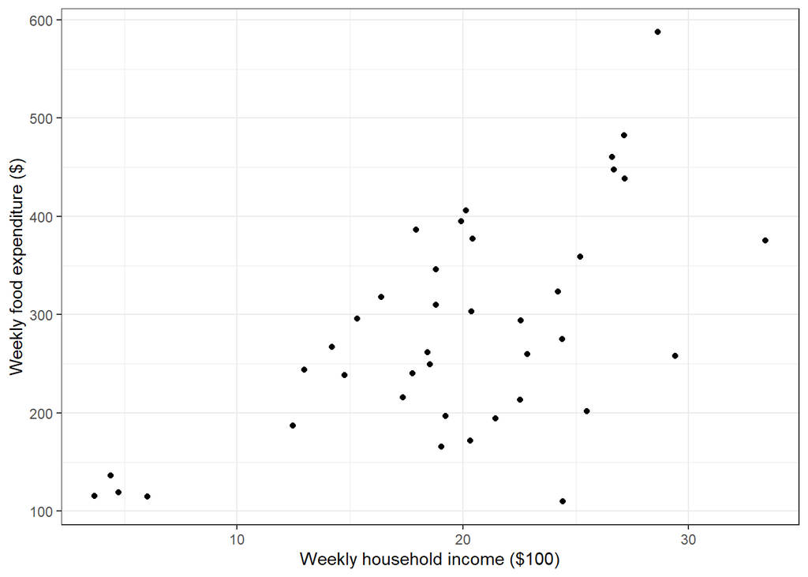

```r
rm(list = ls())
library(mosaic)
#browseURL("http://www.principlesofeconometrics.com/poe5/data/def/food.def")

load(url("http://www.principlesofeconometrics.com/poe5/data/rdata/food.rdata"))

# Scatter plot
food |>
  ggplot(aes(x = income, y = food_exp)) +
  geom_point() +
  xlab("Weekly household income ($100)") +
  ylab("Weekly food expenditure ($)") +theme_bw()
```

Before running any regression: what should we expect?

Look for two things: the upward tendency, and the very large amount of household-to-household variation.

## Start with the simplest model

$$\text{FOOD}= \beta_1 + \beta_2 \times INCOME + e$$

**Show R code**

```r
m_linear <- lm(food_exp ~ income, data = food)
summary(m_linear)
```

```
Call:
lm(formula = food_exp ~ income, data = food)

Residuals:
     Min       1Q   Median       3Q      Max
-223.025  -50.816   -6.324   67.879  212.044

Coefficients:
            Estimate Std. Error t value Pr(>|t|)
(Intercept)   83.416     43.410   1.922   0.0622 .
income        10.210      2.093   4.877 1.95e-05 ***
---
Signif. codes:  0 '***' 0.001 '**' 0.01 '*' 0.05 '.' 0.1 ' ' 1

Residual standard error: 89.52 on 38 degrees of freedom
Multiple R-squared:  0.385, Adjusted R-squared:  0.3688
F-statistic: 23.79 on 1 and 38 DF,  p-value: 1.946e-05
```

**The fitted line is approximately:**

$$\widehat{\text{FOOD}} = 83.42 + 10.21 \times \text{INCOME}$$

**Show R code**

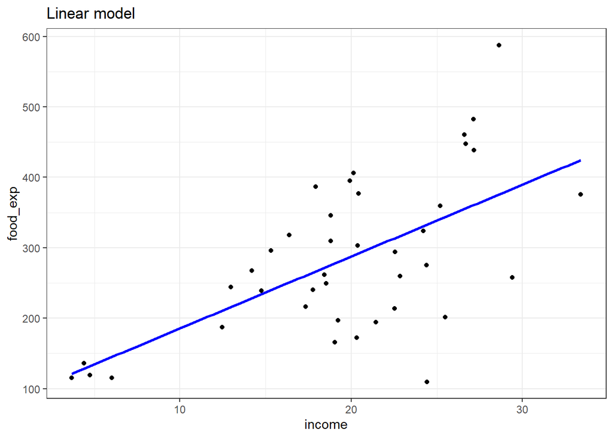

```r
food %>% ggplot(aes(x=income, y=food_exp)) + geom_point() +
  stat_smooth(method=lm, formula = y ~ x, se=FALSE, col="blue")+
  labs(title="Linear model")+
  theme_bw()
```

## Retrieval Questions

**NoteQ1**

Which statement is supported by the regression results?

**A.** Income is statistically significant.

**B.** The model can accurately predict food expenditure for every household.

**C.** Income is significant because its coefficient is positive.

**D.** Income is useful for explaining average food expenditure in the specified model.

**E.** Alternatives A and D are correcta

**NoteQ2**

**Interpreting the intercept.**

The estimated intercept is $83.42$. What does it represent?

**A.** The predicted food expenditure when income equals zero.

**B.** The average food expenditure in the sample.

**C.** The effect of income on food expenditure.

**D.** The unexplained variation in food expenditure.

**NoteQ3**

**Interpreting the slope.**

The estimated coefficient on income is $10.21$. What does this mean?

**A.** A $\$1$ increase in income is associated with a $\$10.21$ increase in food expenditure.

**B.** A $\$100$ increase in income is associated with about a $\$10.21$ increase in food expenditure.

**C.** A $\$10.21$ increase in income is associated with a $\$100$ increase in food expenditure.

**D.** Food expenditure increases by $10.21\%$.

**NoteQ4**

Which null hypothesis is tested by the reported $t-$test for income?

**A.** $H_0:\beta_1=0$

**B.** $H_0:\beta_2=0$

**C.** $H_0:\beta_2>0$

**D.** $H_0:\beta_1 >0$

**So far, we have estimated the relationship between income and food expenditure. We now use the fitted line to make predictions.**

Prediction

Suppose we want to predict food expenditure for **a household** whose weekly income is **$2,000 per week**.

$$\widehat {FOOD} = 83.42 + 10.21(20)=287.62$$

So, our prediction of food expenditure is about:

$$\widehat {FOOD}=287.62 \ \ \text{dollars}$$

- the textbook calls this the **point prediction**.
- **Interpretation:** For a household with an income of $\$2,000$, the model predicts food expenditure of $\$287.62$

**Question**

Suppose there are many households with exactly the same income,$\$2,000$.

Will every household with income=2,000 spend exactly 287.62?

Now imagine many households, all with income $\$2,000$:

| Household | Income | Actual food expenditure |
| --- | --- | --- |
| A | 20 | 250 |
| B | 20 | 275 |
| C | 20 | 300 |
| D | 20 | 325 |

They all have the same $X$, but different $Y$’s.

Why?

Because income is not the only thing affecting food expenditure. Families differ in:

```
  - household size,

  - preferences,

  - location,

  - age,

  - tastes,

  - and many other things.
```

In the **regression model**, all those unobserved influences are represented by the error term $e$.

So, for a particular household with income $\$2,000$, we will have

$$FOOD_i= \widehat {FOOD}+e_i=287.62+e_i$$

Take all households with income $2,000$. Their food expenditures will differ, but they will have some average food expenditure:

$$E(\text{FOOD}|\text{INCOME} = 20) =287.62$$

because $E(e_i|\text{INCOME=20})=0$

- Note that, the regression line gives the average outcome for a given value of $X$.

**Key lesson:** A regression can show a clear average relationship and still be poor at predicting a particular household.

## Connect average prediction and point prediction

- For INCOME $=20$,
  - point prediction for one household $=287.6$.
  - estimated average $\text{FOOD}=287.6$
- So the number is the same. The interpretation is different:

  ```
  - point prediction: the single value we use as our best prediction for one household,

  - average prediction: average food expenditure among households with income 2,000.
  ```

**Note that**, we use the predicted average as our best point prediction for an individual household.

## Prediction/forecast error

- Suppose the household actually spends $\text{Food}=320$ dollars.
- But we predicted $\widehat {FOOD}=287.62$
- Then, the forecast error is:
  $$f= y_0-\widehat y_0$$

$$f= 320-287.6=32.4$$

**Note:** Prediction is not exact because households with the same income can still have different food expenditures.

**Question**

But, instead of giving only one predicted number, can we give a reasonable range?

## Prediction Interval

- The textbook gives the prediction interval as:

$$\hat{y_0} \pm t_cse(f)$$
where, the prediction variance of the error term is given by:

$$\widehat {var}(f|x) =\widehat \sigma^2[1+\frac{1}{N}+\frac{(x_0-\bar x)^2}{\sum_i(x_i-\bar x)^2}]$$

and, the standard error is given by:

$$se(f)=\sqrt{\widehat {var}(f|x)}$$

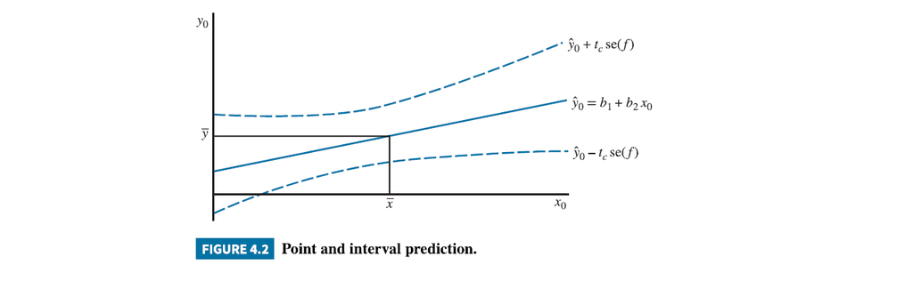

**Question:**Why does uncertainty widen away from the center?

One answer could be we have less sample information about the regression line at more extreme values of income.

- For the income model above, for $\text{INCOME}=20$, the point prediction is about $287.6$, and the $95\%$ prediction interval is approximately:

$$[104.13, 471.09]$$

- This is a range for the actual food expenditure of a particular household with that income.

**Note:**The confidence interval for the average prediction is equal to:$[258.91, 316.31]$

**Question:** Which one is wider/narrower: the prediction interval or the confidence interval?

## Using R

**Show R code**

```r
predict(m_linear,
        newdata = data.frame(income = 20),
        interval = "prediction",
        level = 0.95)
```

```
       fit      lwr      upr
1 287.6089 104.1323 471.0854
```

Alternatively using the `makeFun()` function:

**Show R code**

```r
library(mosaic)
f <- makeFun(m_linear)
f(20, interval="prediction",level=0.95)
```

```
       fit      lwr      upr
1 287.6089 104.1323 471.0854
```

**Show R code**

```r
f(20, interval="confidence",level=0.95)
```

```
       fit      lwr      upr
1 287.6089 258.9069 316.3108
```

The important part is the squared distance term **(x₀ − x̄)²**. Students should understand the logic; they do not need to memorize the formula.

$$|x_0-\bar x|\uparrow \quad\Rightarrow\quad \text{prediction uncertainty}\uparrow.$$

Measuring Goodness-of-Fit, R²

## What does R² tell us — and what does it not tell us?

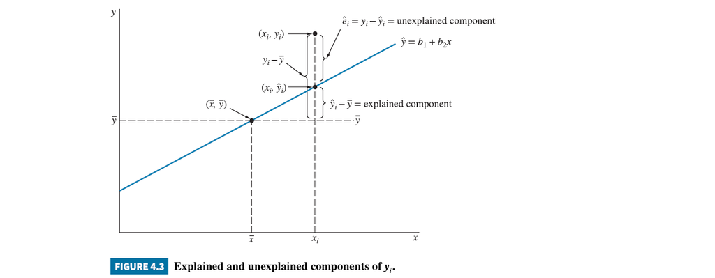

$$R^2=1-\frac{\text{unexplained variation}}{\text{total variation}}$$

$$=1-\frac{SSE}{SST}$$

Interpretation: the proportion of sample variation in $y$ explained by the fitted regression.

**WarningModel-selection trap**

A larger $R^2$ does **not** by itself imply a more economically credible, better specified, or more useful model.

For the linear model:

**R² ≈ 0.385**

Interpretation: about **38.5%** of the sample variation in food expenditure is explained by the linear relationship with income.

Is 0.385 “good” or “bad”?

That question is too simple. R² describes in-sample fit, but it does not tell us whether the model is economically sensible, whether predictions are precise, whether assumptions hold, or whether the functional form is appropriate.

**Common mistake:** “Choose the model with the largest R².”  
This is not a sufficient model-selection rule.

**Reference: SST, SSR, SSE**

Useful for understanding how R² is constructed, but the main lecture emphasis is interpretation rather than hand calculation.

Choosing a Functional Form

The linear model:
$$\widehat {FOOD} = 83.42 + 10.21 × INCOME$$
**Question:** What if the straight line is the wrong economic story?

- What does the linear model tell us?
- Compute the marginal effect:

$$\text{Marginal effect} =d(\widehat{FOOD})/d(INCOME)= 10.21$$

- The linear model says another $\$100$ of income has the same predicted effect everywhere.

**Question:** But should another $100 of income have exactly the same effect at low and high incomes?

**NoteExpected answer**

**No, but possibly a *diminishing marginal effect*.**

A simple alternative is the **linear-log model**:

FOOD = β₁ + β₂ ln(INCOME) + e

**Show R code**

```r
m_linlog <- lm(food_exp ~ log(income), data = food)
summary(m_linlog)
```

```
Call:
lm(formula = food_exp ~ log(income), data = food)

Residuals:
     Min       1Q   Median       3Q      Max
-215.427  -51.666    2.186   47.819  241.548

Coefficients:
            Estimate Std. Error t value Pr(>|t|)
(Intercept)   -97.19      84.24  -1.154    0.256
log(income)   132.17      28.80   4.588 4.76e-05 ***
---
Signif. codes:  0 '***' 0.001 '**' 0.01 '*' 0.05 '.' 0.1 ' ' 1

Residual standard error: 91.57 on 38 degrees of freedom
Multiple R-squared:  0.3565,    Adjusted R-squared:  0.3396
F-statistic: 21.05 on 1 and 38 DF,  p-value: 4.76e-05
```

The fitted equation is approximately:

$$\widehat {FOOD} = −97.19 + 132.17 \times ln(INCOME)$$

**Show R code**

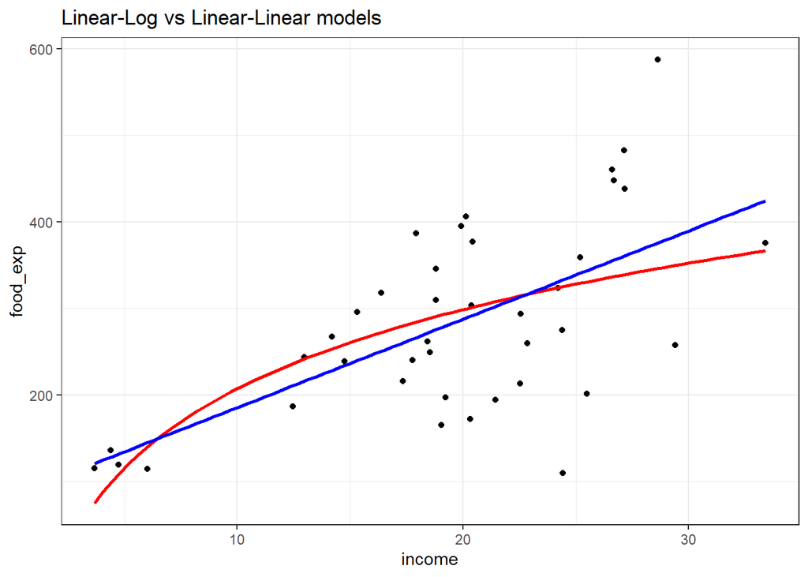

```r
# food %>% ggplot(aes(x=income, y=food_exp)) + geom_point() +
#   stat_smooth(method=lm, formula = y ~ log(x), se=FALSE, col="red")+
#   labs(title="Linear-Log model")+
#   theme_bw()
#
# food %>% ggplot(aes(x=income, y=food_exp)) + geom_point() +
#   stat_smooth(method=lm, formula = y ~ x, se=FALSE, col="blue")+
#   labs(title="Linear-Linear model")+
#   theme_bw()

food %>% ggplot(aes(x=income, y=food_exp)) + geom_point() +
  stat_smooth(method=lm, formula = y ~ log(x), se=FALSE, col="red") +
  stat_smooth(method=lm, se=FALSE, col="blue") +
  labs(title="Linear-Log vs Linear-Linear models")+
    theme_bw()
```

Why might this shape be useful?

Its marginal effect is:

$$d(\widehat {FOOD})/d(INCOME) = 132.17 / INCOME$$

**Show R code**

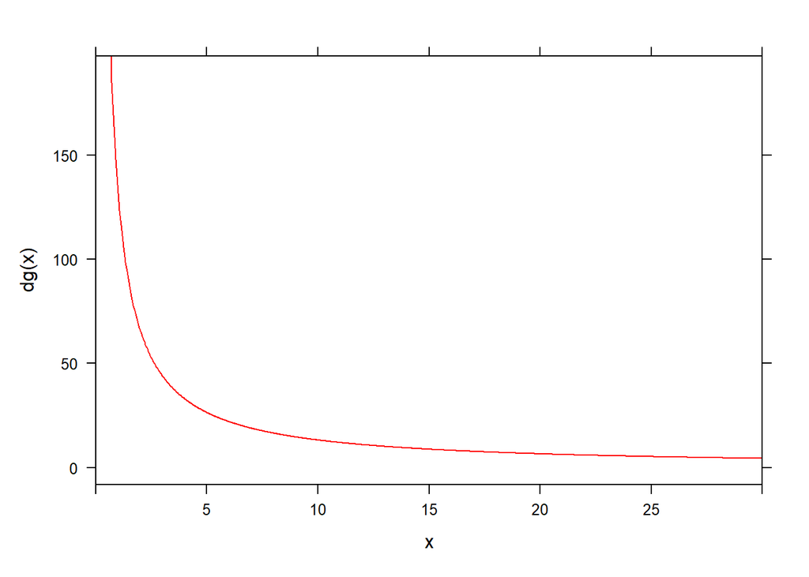

```r
# Slope
g <- makeFun(m_linlog) # E(y|x)

dg <- function(x) {coef(m_linlog)[2]/x}
# diminishing marginal effect
plotFun(dg(x) ~ x, col="red", xlim = c(0,30))
```

**Show R code**

```r
#' E(food_exp|income=10) = ?
g(10)
```

```
       1
207.1367
```

**Show R code**

```r
#' Marginal spending at a 10$ more in income
dg(10)
```

```
log(income)
   13.21658
```

**Show R code**

```r
#' E(food_exp|income=20) = ?
g(20)
```

```
       1
298.7471
```

**Show R code**

```r
#' marginal spending at a 10$ more in income
dg(20)
```

```
log(income)
   6.608292
```

**Show R code**

```r
#' Formula on p. 164 before Example 4.4., $\Delta y \cong \frac{\beta _{2}}{100}(\%\Delta x)$
percent.dg <- function(x) {x*coef(m_linlog)[2]/100}
#' a 1% increase in income will increase food expenditure by `r percent.dg(1)` dollars
percent.dg(1)
```

```
log(income)
   1.321658
```

**Show R code**

```r
percent.dg(10)
```

```
log(income)
   13.21658
```

| Weekly income | Linear model | Linear-log model |
| --- | --- | --- |
| $1,000 | $10.21 per extra $100 | ≈ $13.22 |
| $2,000 | $10.21 | ≈ $6.61 |
| $3,000 | $10.21 | ≈ $4.41 |

**Economic interpretation:** the linear-log model allows additional income to matter more at lower income levels and less at higher income levels.

### But notice the surprise

**Linear model:**  
R² ≈ 0.385

**Linear-log model:**  
R² ≈ 0.357

Should we immediately choose the linear model because 0.385 is larger?

**NoteExpected answer**

**No.** The difference in fit is small, and model choice should also use economic reasoning and diagnostics.

Diagnostics

## Ask the model where it is wrong

A residual is simply:

$$\text{residual} = \text{FOOD} − \widehat {FOOD}$$
$$= \text{observed food expenditure} − \text{predicted food expenditure}$$

What should residuals look like if the model has captured the systematic pattern well?

**Show R code**

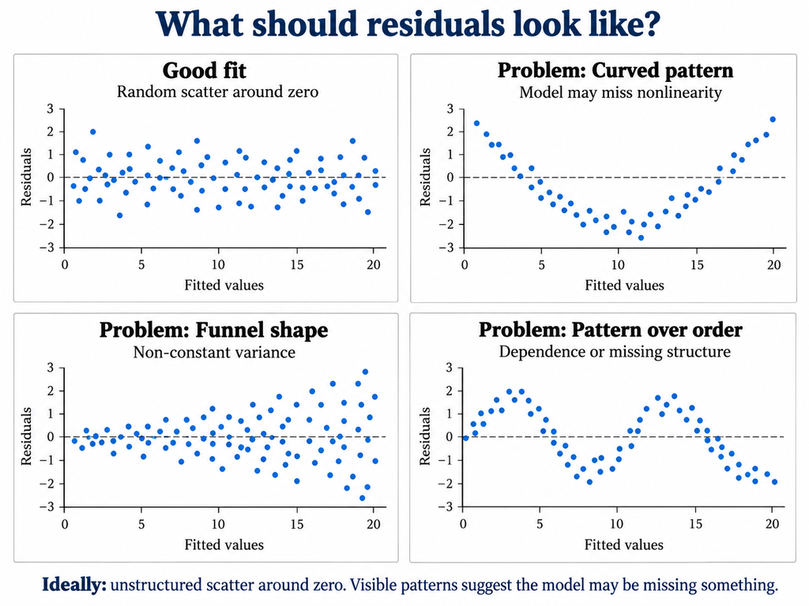

```r
knitr::include_graphics("residuals_plots.png")
```

For the linear food-expenditure data, the residual spread tends to become larger at higher incomes.

**Show R code**

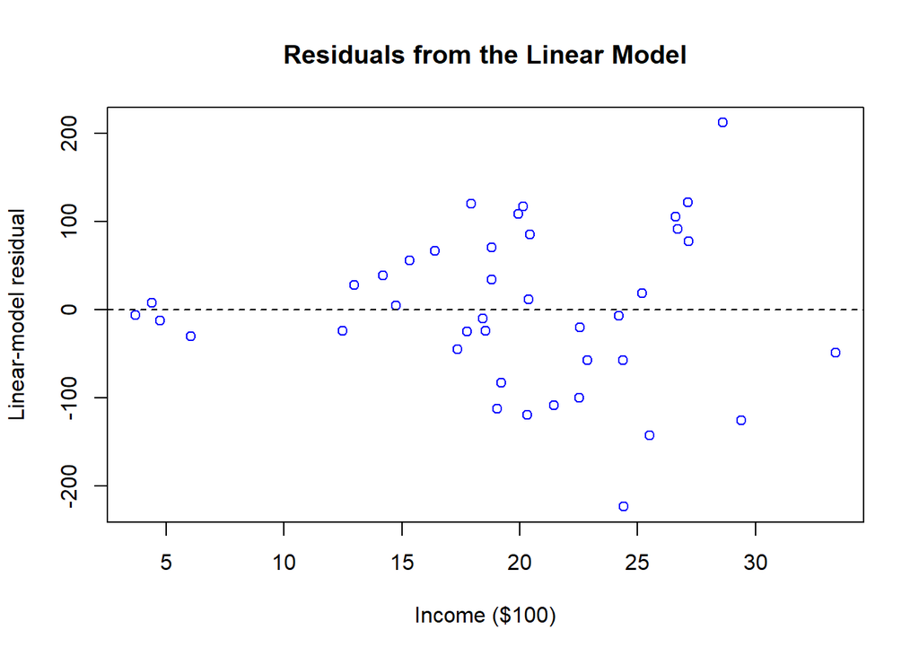

```r
plot(food$income, resid(m_linear),
     xlab = "Income ($100)", ylab = "Linear-model residual", col = "blue",main = "Residuals from the Linear Model")
abline(h = 0, lty = 2)
```

**Changing the functional form may improve the economic story, but it does not automatically solve every modeling problem.**

**Show R code**

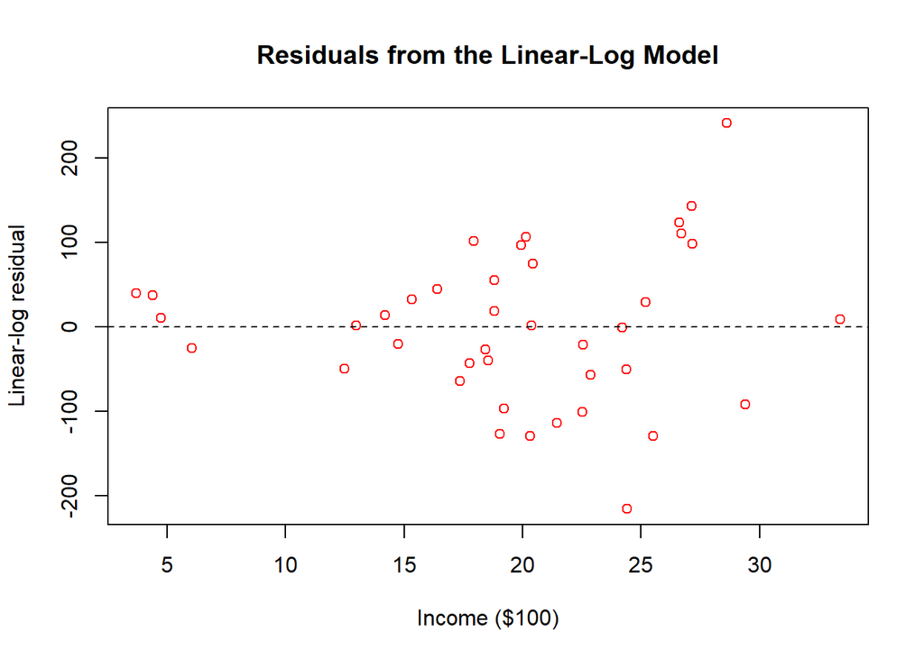

```r
plot(food$income, resid(m_linlog),
     xlab = "Income ($100)",
     ylab = "Linear-log residual",
     col = "red",
     main = "Residuals from the Linear-Log Model")

abline(h = 0, lty = 2)
```

**Show R code**

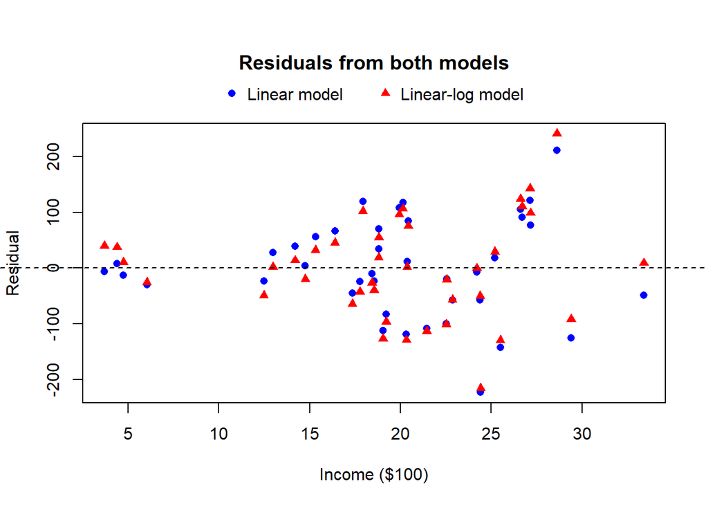

```r
par(mar = c(5, 4, 6, 2) + 0.1, xpd = TRUE)

plot(food$income, resid(m_linear),
     xlab = "Income ($100)",
     ylab = "Residual",
     col = "blue",
     pch = 16,
     ylim = range(c(resid(m_linear), resid(m_linlog))),main = "Residuals from both models")

points(food$income, resid(m_linlog),
       col = "red",
       pch = 17)

abline(h = 0, lty = 2)

legend("top",
       inset = c(0, -0.18),
       legend = c("Linear model", "Linear-log model"),
       col = c("blue", "red"),
       pch = c(16, 17),
       horiz = TRUE,
       bty = "n")
```

This is where students should learn an important habit:

**Estimate → inspect → question → modify → justify**

Put the evidence together

## So, which model should we trust?

We now have several pieces of evidence. None should be used alone.

| Question | What we learned |
| --- | --- |
| Is income related to food expenditure? | Yes, positively. |
| Can the linear model predict an individual household precisely? | No; prediction intervals are very wide. |
| Does the linear model fit the sample? | It explains about 38.5% of the observed variation. |
| Is a constant marginal effect economically compelling? | Not necessarily. |
| Does the linear-log model give a more plausible shape? | Yes, it allows a diminishing marginal effect. |
| Do diagnostics suggest unresolved problems? | Yes; residual variation increases with income. |

**Reasonable conclusion:** Income contains useful information about food expenditure, but neither simple specification should be treated as a highly reliable household-level forecasting model. The linear-log model has an economically attractive shape, yet diagnostics still indicate unresolved issues.

Optional / advanced extension

The following ideas belong in the chapter.

**Influential observations**

Some households are unusual relative to what the model predicts. For example, observations 31 and 38 have large studentized residuals.

| Obs. | Income | Food expenditure | Why interesting? |
| --- | --- | --- | --- |
| 31 | 24.42 | $109.71 | Much lower food spending than the model predicts. |
| 38 | 28.62 | $587.66 | Much higher food spending than the model predicts. |

**Do not teach:** unusual observation → delete.  
**Teach:** identify → investigate → assess influence → justify any action.

**Jarque–Bera / normality**

Use as a reference tool. The important conceptual point is that regression inference concerns the distribution of the *errors*, not whether FOOD or INCOME themselves look normally distributed.

**Scaling, log-linear, log-log, polynomial models**

These are useful extensions and reference material. Teach the logic of choosing a transformation before asking students to memorize several formulas.

**AI Audit**

**Prompt:** “The linear model has R² = 0.385 and the linear-log model has R² = 0.357. Which should an agency use to predict household food expenditure?”

Students should audit whether the answer discusses economic shape, prediction uncertainty, residual diagnostics, and the limits of R².

Exit task

## Can you transfer the idea?

A researcher models household electricity expenditure from income.

**Model A**  
ELECTRICITŶ = 45 + 3.0 INCOME  
R² = 0.42

**Model B**  
ELECTRICITŶ = −10 + 28 ln(INCOME)  
R² = 0.40

Economic reasoning suggests electricity expenditure rises with income but at a decreasing rate. Model B has less curvature in the residuals, but both models show increasing residual spread at high incomes.

Can we say: “Model A is clearly better because 0.42 > 0.40.” What is wrong with that conclusion?

**Show expected answer**

R² alone does not decide the model. Model B is provisionally more consistent with the economic hypothesis and its residual pattern, but the increasing residual spread means the model still needs further diagnostic attention.